# Generisanje slučajnih veličina metodom stohastičke kolokacije

Neka je $Y$ slučajna veličina sa standardnom Košijevom raspodelom, čija je funkcija raspodele data izrazom:

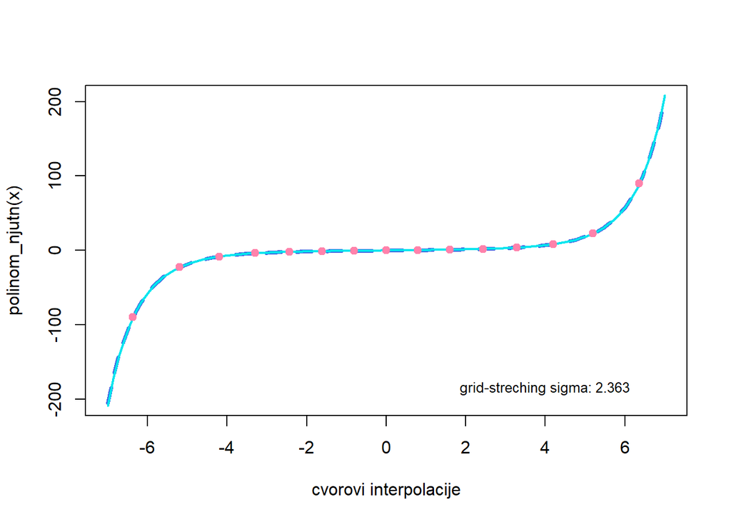

```r
momenti_norm <- function(k, sd = 1) {
  if (k %% 2 == 1) {
    return(0)
  }
  m <- ((sd ^ (k)) * 2 ^ (k / 2) * gamma((k + 1) / 2) / sqrt(pi))
  #m
}

matr_momenata = function(n) {
  B = matrix(data = 0,
             nrow = n + 1,
             ncol = n + 1)
  for (i in 1:(n + 1)) {
    for (j in 1:i) {
      B[i, j] <- momenti_norm(i + j - 2)
      B[j, i] <- momenti_norm(i + j - 2)
    }
  }
  B
}
momenti <- matr_momenata(15)

matricaR <- chol(momenti)
#t(matricaR)%%matricaR

N <- nrow(matricaR)
alfa <- rep(0, N - 1)
for (i in 1:(N - 1)) {
  if (i == 1) {
    alfa[i] <- matricaR[i, i + 1] / matricaR[i, i]
  }
  else{
    alfa[i] <-
      (matricaR[i, i + 1] / matricaR[i, i]) - (matricaR[i - 1, i] / matricaR[i - 1, i - 1])
  }
}

beta <- rep(0, N - 2)

for (i in 1:(N - 2)) {
  beta[i] <- matricaR[i + 1, i + 1] / matricaR[i, i]
  vek_bete <- beta
}

koren_beta <- vek_bete
S <- matrix(data = 0,
            nrow = (N - 1),
            ncol = (N - 1))

for (i in 1:(N - 1)) {
  for (j in 1:i) {
    if (i == j)
      S[i, j] <- alfa[j]
    if ((i == j + 1)) {
      S[i, j] <- koren_beta[j]
      S[j, i] <- koren_beta[j]
    }
  }
}
#S

cvorovi_interpolacije <- eigen(S, only.values = T)
#cvorovi_interpolacije

x <- signif(as.vector(unlist(cvorovi_interpolacije)), digits = 5)
#x
#grid streching

sigma_1 <- x[1] / qnorm(0.99646)
#sigma_2 <- x[1] / qnorm(0.99257)
#sigma_3 <- x[1] / qnorm(0.99766)

fi_sigma1 <- pnorm(x, mean = 0, sigma_1)
#fi_sigma2 <- pnorm(x, mean = 0, sd = sigma_2)
#fi_sigma3 <- pnorm(x, mean = 0, sd = sigma_3)

y <- qcauchy(fi_sigma1)
divided_differences <- function(x, y) {
  n <- length(x)

  q <- matrix(data = 0, n, n - 1)

  for (i in 1:(n - 1)) {
    q[i, 1] = (y[i + 1] - y[i]) / (x[i + 1] - x[i])

  }

  for (j in 2:(n - 1)) {
    for (i in 1:(n - j)) {
      q[i, j] <- (q[i + 1, j - 1] - q[i, j - 1]) / (x[i + j] - x[i])
    }
  }

  return(q)

}

r <- divided_differences(x, y)

coeffs <- c(y[1], r[1,])
cvorovi <- x

njutn <- function(x_0, cvorovi, koeficijenti) {
  n <- length(cvorovi)
  d <- 0
  for (i in n:1) {
    d <- d * (x_0 - cvorovi[i]) + koeficijenti[i]
  }
  return(d)
}

polinom_njutn <- function(x)
  njutn(x, cvorovi, coeffs)
#grafik interpolacije
#isprekidana linija je interpolacija
#svetlo plava linija je teorijska kriva
curve(
  polinom_njutn(x),
  xlim = c(-7, 7),
  col = "royalblue",
  lwd = 3.5,
  lty = 2,
  xlab = "cvorovi interpolacije"
)
text(
  x = 4,
  y = -185,
  labels = "grid-streching sigma: 2.363",
  cex = 0.8
)
curve(qcauchy(pnorm(x, sd = sigma_1)),
      add = TRUE,
      col = "turquoise2",
      lwd = 2)
points(cvorovi,
       polinom_njutn(cvorovi),
       col = "palevioletred1",
       pch = 19)
```

```r
#generišemo uzorak iz normalne N(mean=0,sd=sigma_1)
uzorak_norm <- (sigma_1) * zrnorm(10000)
trazeni_uzorak <- polinom_njutn(uzorak_norm)

#za grafičko predstavljanje podataka biramo box plot, jer je u ovom slučaju pogodniji od histograma
summary(trazeni_uzorak)
```

```
##       Min.    1st Qu.     Median       Mean    3rd Qu.       Max.
## -23520.811     -1.013     -0.010     -0.988      1.000  13636.038
```

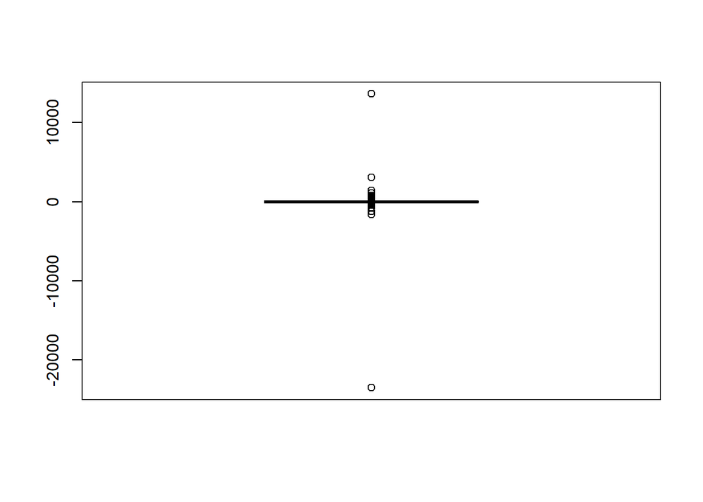

```r
boxplot(trazeni_uzorak)
```

```r
#generišemo uzorak iz standardne Košijeve raspodele pomoću ugrađene fje rcauchy
#uzorak_kosi <- rcauchy(10000)
#primenjujemo testove saglasnosti, zanima nas prvo p vrednost testa

Rp_vrednostiks <- replicate(10, {
  ks.test(rcauchy(10000), function(x)
    pcauchy(x))
}$p.value)
p_vrednostiks <-
  replicate(10, {
    ks.test(polinom_njutn((sigma_1) * zrnorm(10000)), function(x)
      pcauchy(x))
  }$p.value)
mean(Rp_vrednostiks)
```

```
## [1] 0.402582
```

```r
mean(p_vrednostiks)
```

```
## [1] 0.4190085
```

```r
Rp_vrednostiad <- replicate(10, {
  ad.test(rcauchy(10000), function(x)
    pcauchy(x))
}$p.value)
p_vrednostiad <-
  replicate(10, {
    ad.test(polinom_njutn((sigma_1) * zrnorm(10000)), function(x)
      pcauchy(x))
  }$p.value)
mean(Rp_vrednostiad)
```

```
## [1] 0.4536108
```

```r
mean(p_vrednostiad)
```

```
## [1] 0.3697367
```

```r
Rp_vrednosticvm <-
  replicate(10, {
    cvm.test(rcauchy(10000), function(x)
      pcauchy(x))
  }$p.value)
p_vrednosticvm <-
  replicate(10, {
    cvm.test(polinom_njutn((sigma_1) * zrnorm(10000)), function(x)
      pcauchy(x))
  }$p.value)
mean(Rp_vrednosticvm)
```

```
## [1] 0.5485569
```

```r
mean(p_vrednosticvm)
```

```
## [1] 0.5399927
```

```r
#poredimo i test statistike

Rts_ks <- replicate(10, {
  ks.test(rcauchy(10000), function(x)
    pcauchy(x))
}$statistic)
ts_ks <-
  replicate(10, {
    ks.test(polinom_njutn((sigma_1) * zrnorm(10000)), function(x)
      pcauchy(x))
  }$statistic)
mean(Rts_ks)
```

```
## [1] 0.007840157
```

```r
mean(ts_ks)
```

```
## [1] 0.007662564
```

```r
Rts_cvm <- replicate(10, {
  cvm.test(rcauchy(10000), function(x)
    pcauchy(x))
}$statistic)
ts_cvm <-
  replicate(10, {
    cvm.test(polinom_njutn((sigma_1) * zrnorm(10000)), function(x)
      pcauchy(x))
  }$statistic)
mean(Rts_cvm)
```

```
## [1] 0.1263647
```

```r
mean(ts_cvm)
```

```
## [1] 0.1857553
```

```r
Rts_ad <- replicate(10, {
  ad.test(rcauchy(10000), function(x)
    pcauchy(x))
}$statistic)
ts_ad <-
  replicate(10, {
    ad.test(polinom_njutn((sigma_1) * zrnorm(10000)), function(x)
      pcauchy(x))
  }$statistic)
mean(Rts_ad)
```

```
## [1] 1.336862
```

```r
mean(ts_ad)
```

```
## [1] 0.8496993
```

```r
#Napomena: možemo uočiti da vrednosti AD test statistike značajno odsupa od KS i CVM
#ovo se dešava zbog toga sto je AD "osetljivija na repove"
#zbog deljenja izrazom F(x)*(1-F(x)) u integralu, daje veću težinu greskama pri kraju intervala, što ovu test statitiku čini osetljivijom na odstupanja u repovima raspodele
#CVM je srednje-kvadratno odstupanje, a AD je "otezano srednje-kvadratno odstupanje"

#merimo još brzinu generisanja funkcijom microbenchmark

microbenchmark(polinom_njutn(uzorak_norm))
```

```
## Unit: microseconds
##                        expr     min      lq     mean   median       uq
##  polinom_njutn(uzorak_norm) 498.696 528.883 612.9794 537.9395 558.4665
##       max neval
##  3677.426   100
```

```r
microbenchmark(rcauchy(10000))
```

```
## Unit: milliseconds
##            expr      min       lq     mean   median       uq      max
##  rcauchy(10000) 1.182742 1.187874 1.493786 1.438429 1.458654 2.965608
##  neval
##    100
```

```r
#nasa funkcija je brza od ugradjene funkcije u R-u
```

3.GAMA RASPODELA

Ovaj primer predstavlja raspodelu koja je neograničena. Neka je $Y$ slučajna veličina sa gama raspodelom $\Gamma(n,\lambda)$ čija je gustina data kao:

$$f_Y{(x)}=\frac{x^{n-1}e^{-\lambda x}\lambda^{n}}{(n-1)!}, x\geq 0.$$
Kako je ovo pozitivna raspodela, želimo da izvršimo transformaciju uz pomoć funkcije $log$ da dobijemo stvarnu vrednost slučajne veličine, a onda, nakon uzorkovanja koristimo transformaciju uz pomoć funkcije $e$ da dobijemo uzorak iz originalne raspodele. Dakle, koristimo $log{Y}$ umesto $Y$ i uzorkujemo $e^{log{Y}}$ da dobijemo $Y$.

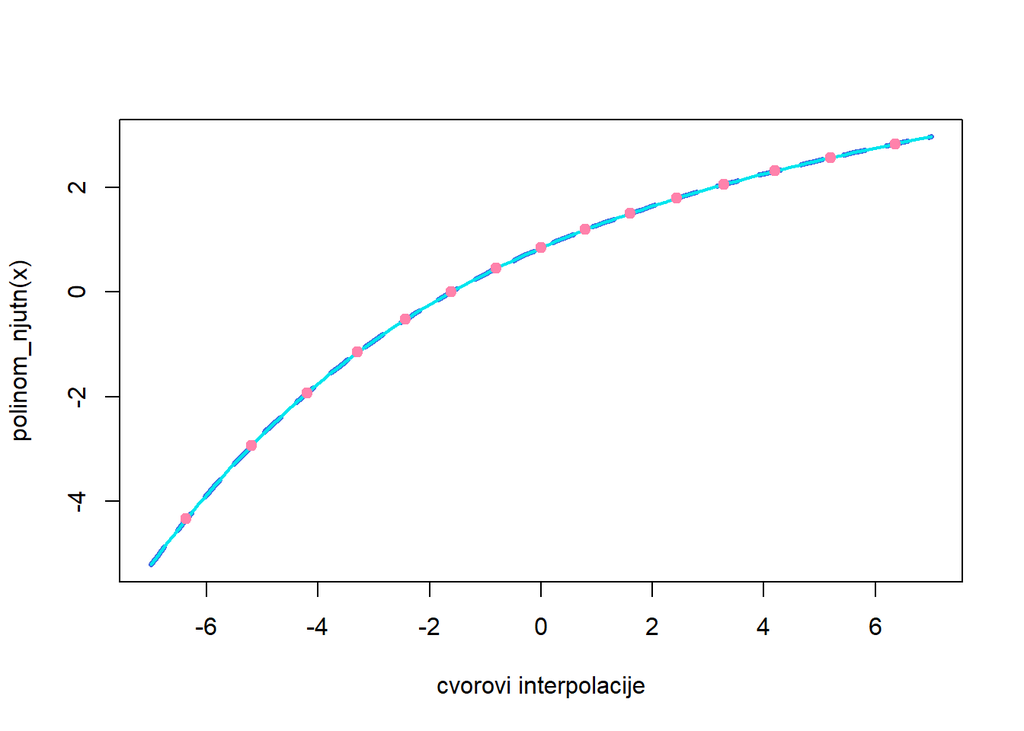

```r
#install.packages("dqrng")
library(dqrng)

momenti_norm <- function(k, sd = 1) {
  if (k %% 2 == 1) {
    return(0)
  }
  m <- ((sd ^ (k)) * 2 ^ (k / 2) * gamma((k + 1) / 2) / sqrt(pi))
  #m
}

matr_momenata = function(n) {
  B = matrix(data = 0,
             nrow = n + 1,
             ncol = n + 1)
  for (i in 1:(n + 1)) {
    for (j in 1:i) {
      B[i, j] <- momenti_norm(i + j - 2)
      B[j, i] <- momenti_norm(i + j - 2)
    }
  }
  B
}
momenti <- matr_momenata(15)

matricaR <- chol(momenti)

#proveravamo identitet A=LL' (ovo nije potrebno za algoritam)
#t(matricaR) %*% matricaR

N <- nrow(matricaR)
alfa <- rep(0, N - 1)
for (i in 1:(N - 1)) {
  if (i == 1) {
    alfa[i] <- matricaR[i, i + 1] / matricaR[i, i]
  }
  else{
    alfa[i] <-
      (matricaR[i, i + 1] / matricaR[i, i]) - (matricaR[i - 1, i] / matricaR[i - 1, i - 1])
  }
}

beta <- rep(0, N - 2)

for (i in 1:(N - 2)) {
  beta[i] <- matricaR[i + 1, i + 1] / matricaR[i, i]
  vek_bete <- beta
}

koren_beta <- vek_bete
S <- matrix(data = 0,
            nrow = (N - 1),
            ncol = (N - 1))


for (i in 1:(N - 1)) {
  for (j in 1:i) {
    if (i == j)
      S[i, j] <- alfa[j]
    if ((i == j + 1)) {
      S[i, j] <- koren_beta[j]
      S[j, i] <- koren_beta[j]
    }
  }
}
#S

cvorovi_interpolacije <- eigen(S, only.values = T)
#cvorovi_interpolacije

x <- signif(as.vector(unlist(cvorovi_interpolacije)), digits = 5)
#x

z<-pnorm(x)
#z
#izracunali smo cvorove
#radimo transformaciju
y<-log(qgamma(z,5,2))

divided_differences <- function(x, y) {
  n <- length(x)

  q <- matrix(data = 0, n, n - 1)

  for (i in 1:(n - 1)) {
    q[i, 1] = (y[i + 1] - y[i]) / (x[i + 1] - x[i])

  }

   for (j in 2:(n - 1)) {
    for (i in 1:(n - j)) {
      q[i, j] <- (q[i + 1, j - 1] - q[i, j - 1]) / (x[i + j] - x[i])

    }
  }
  return(q)

}

r <- divided_differences(x, y)
coeffs <- c(y[1], r[1, ])
cvorovi <- x

#njutnov interpolacioni polinom implementiran pomocu Hornerove sheme

njutn <- function(x_0, cvorovi, koeficijenti) {
  n <- length(cvorovi)
  d <- 0
  for (i in n:1) {
    d <- d * (x_0 - cvorovi[i]) + koeficijenti[i]
  }
  return(d)
}

polinom_njutn <- function(x)
  njutn(x, cvorovi, coeffs)

#grafik interpolacije
#isprekidana linija je interpolacija
#svetlo plava linija je teorijska kriva

curve(
  polinom_njutn(x),
  col = "royalblue",
  lwd = 3.5,
  lty = 2,
  xlim=c(-7,7),
  xlab = "cvorovi interpolacije"
)
curve(log(qgamma((pnorm(x)),5,2)),
      add = TRUE,
      col = "turquoise2",
      lwd = 2)
points(cvorovi,
       polinom_njutn(cvorovi),
       col = "palevioletred1",
       pch = 19)
```

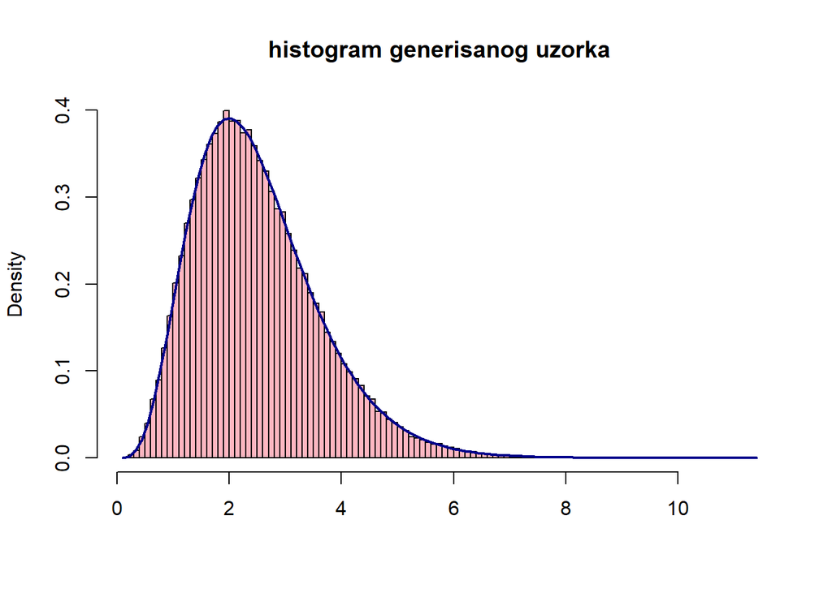

```r
uzorak<-zrnorm(100000)
trazeni_uzorak <- polinom_njutn(uzorak)

hist(
  breaks = 100,
  exp(trazeni_uzorak),
  probability = TRUE,
  main = "histogram generisanog uzorka",
  xlab = NULL,
  col = "lightpink"
)
curve(
  dgamma(x, 5,2),
  add = TRUE,
  col = "darkblue",
  lwd = 2
)
```

```r
Rp_vrednostiks <- replicate(10, {
  ks.test(rgamma(100000, 5, 2), function(x)
    pgamma(x, 5, 2))
}$p.value)
p_vrednostiks <-
  replicate(10, {
    ks.test(exp(trazeni_uzorak), function(x)
      pgamma(x, 5, 2))
  }$p.value)
mean(Rp_vrednostiks)
```

```
## [1] 0.4504647
```

```r
mean(p_vrednostiks)
```

```
## [1] 0.8832984
```

```r
Rp_vrednostiad <- replicate(10, {
  ad.test(rgamma(100000, 5, 2), function(x)
    pgamma(x, 5, 2))
}$p.value)
p_vrednostiad <-
  replicate(10, {
    ad.test(exp(trazeni_uzorak), function(x)
      pgamma(x, 5, 2))
  }$p.value)
mean(Rp_vrednostiad)
```

```
## [1] 0.50079
```

```r
mean(p_vrednostiad)
```

```
## [1] 0.9735709
```

```r
Rp_vrednosticvm <- replicate(10, {
  cvm.test(rgamma(100000, 5, 2), function(x)
    pgamma(x, 5, 2))
}$p.value)
p_vrednosticvm <-
  replicate(10, {
    cvm.test(exp(trazeni_uzorak), function(x)
      pgamma(x, 5, 2))
  }$p.value)
mean(Rp_vrednosticvm)
```

```
## [1] 0.4430306
```

```r
mean(p_vrednosticvm)
```

```
## [1] 0.9527384
```

```r
microbenchmark(polinom_njutn(uzorak))
```

```
## Unit: milliseconds
##                   expr      min       lq    mean   median       uq
##  polinom_njutn(uzorak) 6.326669 6.868231 10.4727 7.781398 10.07534
##       max neval
##  52.48376   100
```

```r
microbenchmark(rgamma(100000,5,2))
```

```
## Unit: milliseconds
##                 expr      min       lq     mean   median       uq      max
##  rgamma(1e+05, 5, 2) 19.74676 20.24003 24.13761 21.44028 25.70545 46.38832
##  neval
##    100
```

4.$\chi^{2}$ RASPODELA

Neka je $Y$ slučajna veličina sa $\chi^{2}$ raspodelom. Ona je definisana kao zbir kvadrata k standardno normalno raspodeljenih slučajnih veličina i njena gustina je data izrazom:

$$f_Y{(x)}=\frac{x^{\frac{k}{2}-1}e^{-\frac{x}{2}}}{2^{\frac{k}{2}}\Gamma(\frac{k}{2})},x\in [0,\infty)$$
, gde je $k$ broj stepeni slobode. Za primenu metode stohastičke kolokacije, koristimo pomoćnu slučajnu veličinu $X$ sa standardnom normalnom raspodelom, a čvorove interpolacije biramo kao optimalne u srednjekvadratnom smislu

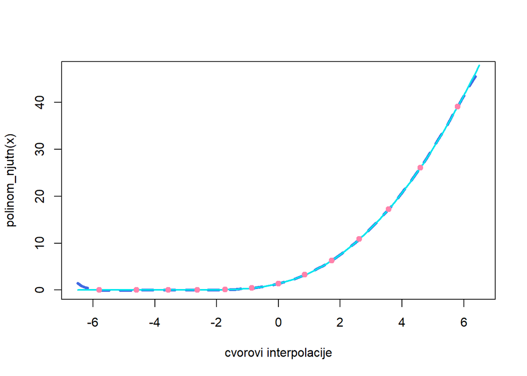

```r
momenti_norm <- function(k, sd = 1) {
  if (k %% 2 == 1) {
    return(0)
  }
  m <- ((sd ^ (k)) * 2 ^ (k / 2) * gamma((k + 1) / 2) / sqrt(pi))
  #m
}

matr_momenata = function(n) {
  B = matrix(data = 0,
             nrow = n + 1,
             ncol = n + 1)
  for (i in 1:(n + 1)) {
    for (j in 1:i) {
      B[i, j] <- momenti_norm(i + j - 2)
      B[j, i] <- momenti_norm(i + j - 2)
    }
  }
 B
}
momenti <- matr_momenata(13)

matricaR <- chol(momenti)

N <- nrow(matricaR)
alfa <- rep(0, N - 1)
for (i in 1:(N - 1)) {
  if (i == 1) {
    alfa[i] <- matricaR[i, i + 1] / matricaR[i, i]
  }
  else{
    alfa[i] <-
      (matricaR[i, i + 1] / matricaR[i, i]) - (matricaR[i - 1, i] / matricaR[i - 1, i - 1])
  }
}

beta <- rep(0, N - 2)

for (i in 1:(N - 2)) {
  beta[i] <- matricaR[i + 1, i + 1] / matricaR[i, i]
  vek_bete <- beta
}

koren_beta <- vek_bete
S <- matrix(data = 0,
            nrow = (N - 1),
            ncol = (N - 1))


for (i in 1:(N - 1)) {
  for (j in 1:i) {
    if (i == j)
      S[i, j] <- alfa[j]
    if ((i == j + 1)) {
      S[i, j] <- koren_beta[j]
      S[j, i] <- koren_beta[j]
    }
  }
}
#S

cvorovi_interpolacije <- eigen(S, only.values = T)
#cvorovi_interpolacije

x <- signif(as.vector(unlist(cvorovi_interpolacije)), digits = 5)
#x
z<-pnorm(x)
#z
#izracunali smo cvorove
y<-qchisq(z,2)

divided_differences <- function(x, y) {
  n <- length(x)

  q <- matrix(data = 0, n, n - 1)

  for (i in 1:(n - 1)) {
    q[i, 1] = (y[i + 1] - y[i]) / (x[i + 1] - x[i])
  }

  for (j in 2:(n - 1)) {
    for (i in 1:(n - j)) {
      q[i, j] <- (q[i + 1, j - 1] - q[i, j - 1]) / (x[i + j] - x[i])
    }
  }
  return(q)
}

r <- divided_differences(x, y)
coeffs <- c(y[1], r[1, ])
cvorovi <- x

#njutnov interpolacioni polinom implementiran pomocu Hornerove sheme

njutn <- function(x_0, cvorovi, koeficijenti) {
  n <- length(cvorovi)
  d <- 0
  for (i in n:1) {
    d <- d * (x_0 - cvorovi[i]) + koeficijenti[i]
  }
  return(d)
}

polinom_njutn <- function(x)
  njutn(x, cvorovi, coeffs)

#grafik interpolacije
#isprekidana linija je interpolacija
#svetlo plava linija je teorijska kriva
curve(
  polinom_njutn(x),
  xlim = c(-6.5, 6.5),
  col = "royalblue",
  lwd = 3.5,
  lty = 2,
  xlab = "cvorovi interpolacije"
)

curve(qchisq(pnorm(x),2),
      add = TRUE,
      col = "turquoise2",
      lwd = 2)
points(cvorovi,
       polinom_njutn(cvorovi),
       col = "palevioletred1",
       pch = 19)
```

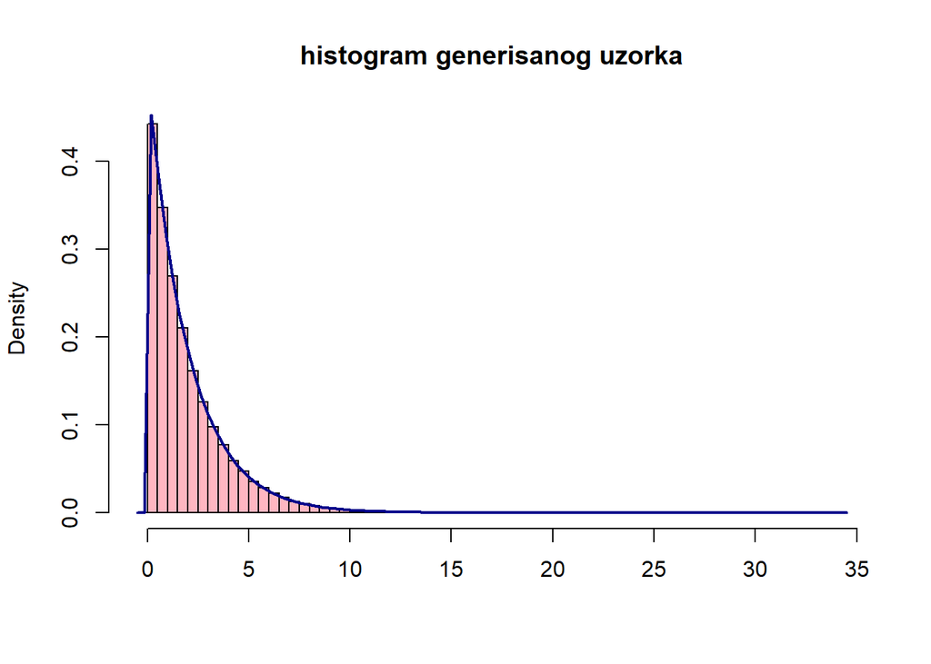

```r
uzorak<-zrnorm(100000)
trazeni_uzorak <- polinom_njutn(uzorak)

hist(
  breaks = 50,
  trazeni_uzorak,
  probability = TRUE,
  main = "histogram generisanog uzorka",
  xlab = NULL,
  col = "lightpink"
)

curve(
  dchisq(x, 2),
  add = TRUE,
  col = "darkblue",
  lwd = 2
)
```

```r
uzorak<-zrnorm(100000)
trazeni_uzorak <- polinom_njutn(uzorak)



Rp_vrednostiks <- replicate(10, {
  ks.test(rchisq(100000, 2), function(x)
    pchisq(x, 2))
}$p.value)
p_vrednostiks <-
  replicate(10, {
    ks.test(trazeni_uzorak, function(x)
      pchisq(x, 2))
  }$p.value)
mean(Rp_vrednostiks)
```

```
## [1] 0.3157881
```

```r
mean(p_vrednostiks)
```

```
## [1] 0.8050125
```

```r
Rp_vrednostiad <- replicate(10, {
  ad.test(rchisq(100000, 2), function(x)
    pchisq(x, 2))
}$p.value)
p_vrednostiad <-
  replicate(10, {
    ad.test(trazeni_uzorak, function(x)
      pchisq(x, 2))
  }$p.value)
mean(Rp_vrednostiad)
```

```
## [1] 0.6333923
```

```r
mean(p_vrednostiad)
```

```
## [1] 6e-09
```

```r
Rp_vrednosticvm <- replicate(10, {
  cvm.test(rchisq(100000, 2), function(x)
    pchisq(x,2))
}$p.value)
p_vrednosticvm <-
  replicate(10, {
    cvm.test(trazeni_uzorak, function(x)
      pchisq(x,2))
  }$p.value)
mean(Rp_vrednosticvm)
```

```
## [1] 0.4598056
```

```r
mean(p_vrednosticvm)
```

```
## [1] 0.6616524
```

```r
microbenchmark(polinom_njutn(uzorak))
```

```
## Unit: milliseconds
##                   expr      min       lq     mean  median       uq
##  polinom_njutn(uzorak) 5.461499 6.021777 8.273525 7.54473 9.144358
##       max neval
##  18.63647   100
```

```r
microbenchmark(rchisq(100000,2))
```

```
## Unit: milliseconds
##              expr      min       lq    mean   median       uq      max
##  rchisq(1e+05, 2) 27.32983 27.86988 30.9337 29.13715 32.69654 53.68763
##  neval
##    100
```

5.LOGISTIČKA RASPODELA

Slučajna veličina $Y$ sa logističkom raspodelom ima funkciju raspodele

$$F_Y{(x)}=\frac{e^x}{1+e^x},x\in \mathbb{R}.$$
Za pomoćnu slučajnu veličinu koristimo slučajnu veličinu $X$ sa normalnom raspodelom, a čvorove interpolacije određujemo kao optimalne čvorove u srednje kvadratnom smislu.

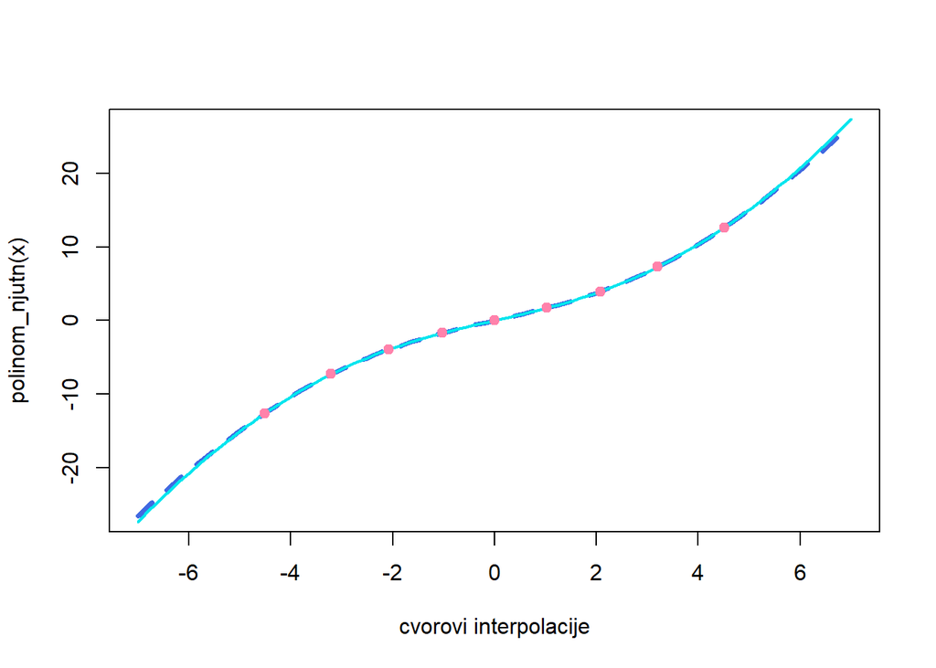

```r
momenti_norm <- function(k, sd = 1) {
  if (k %% 2 == 1) {
    return(0)
  }
  m <- ((sd ^ (k)) * 2 ^ (k / 2) * gamma((k + 1) / 2) / sqrt(pi))
  #m
}

matr_momenata = function(n) {
  B = matrix(data = 0,
             nrow = n + 1,
             ncol = n + 1)
  for (i in 1:(n + 1)) {
    for (j in 1:i) {
      B[i, j] <- momenti_norm(i + j - 2)
      B[j, i] <- momenti_norm(i + j - 2)
    }
  }
  B
}
momenti <- matr_momenata(9)

matricaR <- chol(momenti)

#proveravamo identitet A=LL' (ovo nije potrebn za algoritam)
#t(matricaR) %*% matricaR


N <- nrow(matricaR)
alfa <- rep(0, N - 1)
for (i in 1:(N - 1)) {
  if (i == 1) {
    alfa[i] <- matricaR[i, i + 1] / matricaR[i, i]
  }
  else{
    alfa[i] <-
      (matricaR[i, i + 1] / matricaR[i, i]) - (matricaR[i - 1, i] / matricaR[i - 1, i - 1])
  }
}

beta <- rep(0, N - 2)

for (i in 1:(N - 2)) {
  beta[i] <- matricaR[i + 1, i + 1] / matricaR[i, i]
  vek_bete <- beta
}

koren_beta <- vek_bete
S <- matrix(data = 0,
            nrow = (N - 1),
            ncol = (N - 1))


for (i in 1:(N - 1)) {
  for (j in 1:i) {
    if (i == j)
      S[i, j] <- alfa[j]
    if ((i == j + 1)) {
      S[i, j] <- koren_beta[j]
      S[j, i] <- koren_beta[j]
    }
  }
}
#S

cvorovi_interpolacije <- eigen(S, only.values = T)
#cvorovi_interpolacije

x <- signif(as.vector(unlist(cvorovi_interpolacije)), digits = 5)
#x

x_norm <- pnorm(x)
y <- qlogis(x_norm)
cvorovi <- x

divided_differences <- function(x, y) {

  n <- length(x)

  q <- matrix(data = 0, n, n - 1)

  for (i in 1:(n - 1)) {
    q[i, 1] = (y[i + 1] - y[i]) / (x[i + 1] - x[i])

  }
  for (j in 2:(n - 1)) {
    for (i in 1:(n - j)) {
      q[i, j] <- (q[i + 1, j - 1] - q[i, j - 1]) / (x[i + j] - x[i])

    }
  }
  return(q)

}

r <- divided_differences(x, y)
coeffs <- c(y[1], r[1, ])
cvorovi <- x
#njutnov interpolacioni polinom

njutn <- function(x_0, cvorovi, koeficijenti) {
  n <- length(cvorovi)
  d <- 0
  for (i in n:1) {
    d <- d * (x_0 - cvorovi[i]) + koeficijenti[i]
  }
  return(d)
}

polinom_njutn <- function(x)
  njutn(x, cvorovi, coeffs)

#grafik interpolacije
#isprekidana linija je interpolacija
#svetlo plava linija je teorijska kriva
curve(
  polinom_njutn(x),
  col = "royalblue",
  xlim = c(-7, 7),
  lwd = 3.5,
  lty = 2,
  xlab = "cvorovi interpolacije"
)

curve(qlogis(pnorm(x)),
      add = TRUE,
      col = "turquoise2",
      lwd = 2)

points(cvorovi,
       polinom_njutn(cvorovi),
       col = "palevioletred1",
       pch = 19)
```

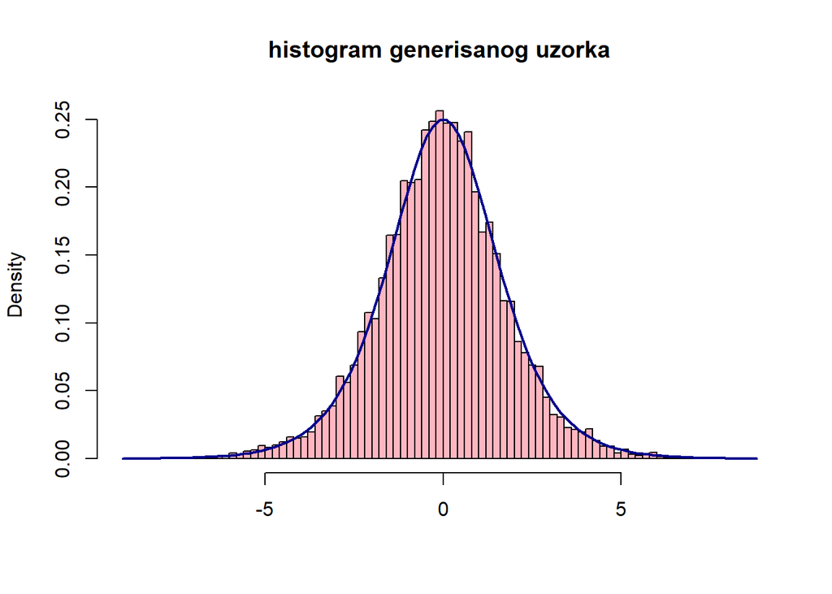

```r
uz_pom <- zrnorm(10000)
trazeni_uz <- polinom_njutn(uz_pom)

hist(
  breaks = 100,
  trazeni_uz,
  probability = TRUE,
  main = "histogram generisanog uzorka",
  xlab = NULL,
  col = "lightpink"
)
curve(dlogis(x),
      add = TRUE,
      col = "darkblue",
      lwd = 2)
```

```r
#vrednosti pet sumarnih statistika dobijamo pokretanjem funkcije summary na uzorku
summary(trazeni_uz)
```

```
##     Min.  1st Qu.   Median     Mean  3rd Qu.     Max.
## -8.80269 -1.14365 -0.04069 -0.04496  1.04029  8.75022
```

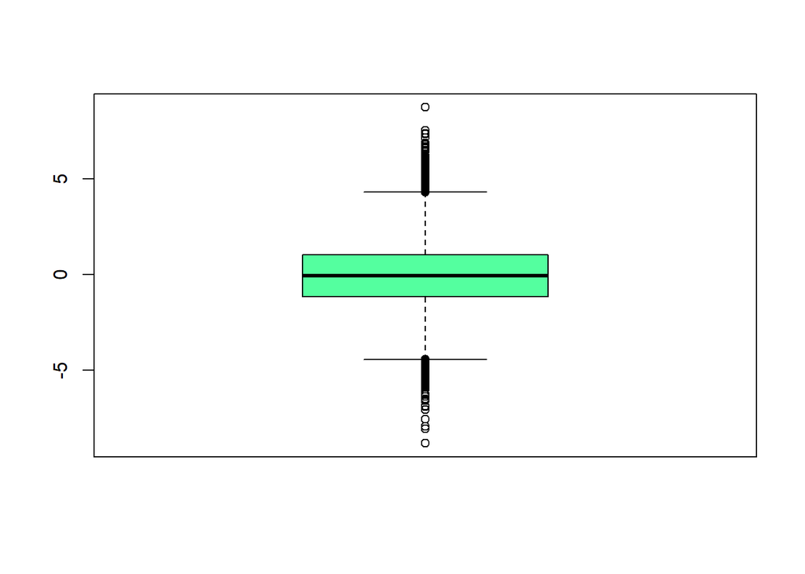

```r
boxplot(trazeni_uz, col = "seagreen1")
```

```r
#testovi saglasnosti
Rp_vrednostiks <- replicate(10, {
  ks.test(rlogis(10000), function(x)
    plogis(x))
}$p.value)
p_vrednostiks <-
  replicate(10, {
    ks.test(polinom_njutn(zrnorm(10000)), function(x)
      plogis(x))
  }$p.value)
mean(Rp_vrednostiks)
```

```
## [1] 0.4141221
```

```r
mean(p_vrednostiks)
```

```
## [1] 0.4670276
```

```r
Rp_vrednosticvm <- replicate(10, {
  cvm.test(rlogis(10000), function(x)
    plogis(x))
}$p.value)
p_vrednosticvm <-
  replicate(10, {
    cvm.test(polinom_njutn(zrnorm(10000)), function(x)
      plogis(x))
  }$p.value)
mean(Rp_vrednosticvm)
```

```
## [1] 0.5809299
```

```r
mean(p_vrednosticvm)
```

```
## [1] 0.6615536
```

```r
Rp_vrednostiad <- replicate(10, {
  ad.test(rlogis(10000), function(x)
    plogis(x))
}$p.value)
p_vrednostiad <-
  replicate(10, {
    ad.test(polinom_njutn(zrnorm(10000)), function(x)
      plogis(x))
  }$p.value)
mean(Rp_vrednostiad)
```

```
## [1] 0.3472343
```

```r
mean(p_vrednostiad)
```

```
## [1] 0.4830151
```

```r
microbenchmark(polinom_njutn(zrnorm(10000)))
```

```
## Unit: microseconds
##                          expr     min      lq    mean  median       uq
##  polinom_njutn(zrnorm(10000)) 447.377 520.733 574.569 544.581 555.4485
##       max neval
##  3637.579   100
```

```r
microbenchmark(rlogis(10000))
```

```
## Unit: milliseconds
##           expr      min       lq     mean   median       uq      max neval
##  rlogis(10000) 1.300472 1.305001 1.396583 1.309529 1.329754 2.572568   100
```